# Trip Advisor: What consitutes hotel popularity?

**Project Description**:

In this project, I am using a dataset consisting of 272 columns, describing 4,599 hotels located in Rome, Italy. The goal of this project is to untangle this significant amount of data to create insight around which pieces of information impact the popularity of a hotel, measured by its clicks on the Trip Advisor platform.

The challenge of this dataset and this mission is plentiful. At first glance, the high dimensionality appears to offer a lot of potential insight, but can also problems on tasks of causal inference/discovery, discovering patterns, or creating models with high predictive power. In other words, while the dataset is able to provide a lot of detail about the different listed hotels, such as aminities, number of photos, and many others, their relevance can be misleading in the quest of finding causal relationships and their weight. Reasons further include computational complexity and overfitting in modeling. Oftentimes, applying dimensionality reduction techniques can prove helpful to overcome such weaknesses and can consequently allow a model to include only the most relevant features that can best explain a target variable.

In this project, I first analyze the underlying data structure and conduct data cleaning. Then, I apply ML/Ensemble methods with a Cross-validation approach to reduce bias in identifying potentially relevant features, i.e. performing feature selection. Using the different feature importance results, Causal Inference Analysis is then conducted with these features on the target variable, in order to uncover the causal structure among them.

```python
# load required packages

import pandas as pd
import matplotlib.pyplot as plt
import seaborn as sns
import numpy as np
import warnings
warnings.filterwarnings('ignore')
```

```python
# load the trip advisor data

data_raw = pd.read_csv('C:/Users/felix/OneDrive/Dokumente/Python Projects/Causal_Discovery_And_Inference/TripAdvisor_data.csv', delimiter=',', encoding='cp1252')

data_raw.head()
```

|  | Unnamed: 0 | hotel_url | name | views | views_binary | score_adjusted | bubble_rating | category_hotel | category_inn | category_specialty | ... | amenities_Wardrobe / closet | amenities_Washing machine | amenities_Water park | amenities_Water park offsite | amenities_Waterslide | amenities_Waxing services | amenities_Whirlpool bathtub | amenities_Wifi | amenities_Wine / champagne | amenities_Yoga classes |
| --- | --- | --- | --- | --- | --- | --- | --- | --- | --- | --- | --- | --- | --- | --- | --- | --- | --- | --- | --- | --- | --- |
| 0 | 1 | https://www.tripadvisor.com/Hotel_Review-g1877... | Casa Mia in Trastevere | 0 | 0 | 4.409091 | 4.5 | 0 | 1 | 0 | ... | 0 | 0 | 0 | 0 | 0 | 0 | 0 | 1 | 1 | 0 |
| 1 | 2 | https://www.tripadvisor.com/Hotel_Review-g1877... | Hotel Artemide | 88 | 1 | 4.798118 | 5.0 | 1 | 0 | 0 | ... | 1 | 1 | 0 | 0 | 0 | 0 | 0 | 1 | 0 | 0 |
| 2 | 3 | https://www.tripadvisor.com/Hotel_Review-g1877... | A.Roma Lifestyle Hotel | 32 | 1 | 4.634085 | 4.5 | 1 | 0 | 0 | ... | 0 | 0 | 0 | 0 | 0 | 0 | 0 | 1 | 0 | 0 |
| 3 | 4 | https://www.tripadvisor.com/Hotel_Review-g1877... | iQ Hotel Roma | 17 | 1 | 4.699138 | 4.5 | 1 | 0 | 0 | ... | 1 | 1 | 0 | 0 | 0 | 0 | 0 | 1 | 1 | 0 |
| 4 | 5 | https://www.tripadvisor.com/Hotel_Review-g1877... | The Guardian | 0 | 0 | 4.624299 | 4.5 | 1 | 0 | 0 | ... | 0 | 0 | 0 | 0 | 0 | 0 | 0 | 1 | 0 | 0 |

5 rows × 272 columns

```python
data_raw.info()
```

```
<class 'pandas.core.frame.DataFrame'>
RangeIndex: 4599 entries, 0 to 4598
Columns: 272 entries, Unnamed: 0 to amenities_Yoga classes
dtypes: float64(8), int64(261), object(3)
memory usage: 9.5+ MB
```

```python
data_raw.describe()

# as can be seen below, 3 features, such as hotel_url and name, cannot be statistically described because of their categorical nature
```

|  | Unnamed: 0 | views | views_binary | score_adjusted | bubble_rating | category_hotel | category_inn | category_specialty | class_4_5 | class_3_4_5 | ... | amenities_Wardrobe / closet | amenities_Washing machine | amenities_Water park | amenities_Water park offsite | amenities_Waterslide | amenities_Waxing services | amenities_Whirlpool bathtub | amenities_Wifi | amenities_Wine / champagne | amenities_Yoga classes |
| --- | --- | --- | --- | --- | --- | --- | --- | --- | --- | --- | --- | --- | --- | --- | --- | --- | --- | --- | --- | --- | --- |
| count | 4599.000000 | 4599.000000 | 4599.000000 | 4599.000000 | 4599.000000 | 4599.000000 | 4599.000000 | 4599.000000 | 4599.000000 | 4599.000000 | ... | 4599.000000 | 4599.000000 | 4599.000000 | 4599.000000 | 4599.000000 | 4599.000000 | 4599.000000 | 4599.000000 | 4599.000000 | 4599.000000 |
| mean | 2300.000000 | 0.274625 | 0.037399 | 4.058395 | 4.067841 | 0.190041 | 0.619482 | 0.190476 | 0.111763 | 0.295934 | ... | 0.025440 | 0.020874 | 0.000435 | 0.000870 | 0.000217 | 0.002609 | 0.004784 | 0.648619 | 0.072624 | 0.001522 |
| std | 1327.761274 | 2.231304 | 0.189759 | 0.837018 | 0.850739 | 0.392376 | 0.485567 | 0.392719 | 0.315109 | 0.456511 | ... | 0.157475 | 0.142978 | 0.020851 | 0.029482 | 0.014746 | 0.051020 | 0.069006 | 0.477454 | 0.259547 | 0.038988 |
| min | 1.000000 | 0.000000 | 0.000000 | 1.000000 | 1.000000 | 0.000000 | 0.000000 | 0.000000 | 0.000000 | 0.000000 | ... | 0.000000 | 0.000000 | 0.000000 | 0.000000 | 0.000000 | 0.000000 | 0.000000 | 0.000000 | 0.000000 | 0.000000 |
| 25% | 1150.500000 | 0.000000 | 0.000000 | 3.673771 | 3.500000 | 0.000000 | 0.000000 | 0.000000 | 0.000000 | 0.000000 | ... | 0.000000 | 0.000000 | 0.000000 | 0.000000 | 0.000000 | 0.000000 | 0.000000 | 0.000000 | 0.000000 | 0.000000 |
| 50% | 2300.000000 | 0.000000 | 0.000000 | 4.282051 | 4.500000 | 0.000000 | 1.000000 | 0.000000 | 0.000000 | 0.000000 | ... | 0.000000 | 0.000000 | 0.000000 | 0.000000 | 0.000000 | 0.000000 | 0.000000 | 1.000000 | 0.000000 | 0.000000 |
| 75% | 3449.500000 | 0.000000 | 0.000000 | 4.666667 | 4.500000 | 0.000000 | 1.000000 | 0.000000 | 0.000000 | 1.000000 | ... | 0.000000 | 0.000000 | 0.000000 | 0.000000 | 0.000000 | 0.000000 | 0.000000 | 1.000000 | 0.000000 | 0.000000 |
| max | 4599.000000 | 88.000000 | 1.000000 | 5.000000 | 5.000000 | 1.000000 | 1.000000 | 1.000000 | 1.000000 | 1.000000 | ... | 1.000000 | 1.000000 | 1.000000 | 1.000000 | 1.000000 | 1.000000 | 1.000000 | 1.000000 | 1.000000 | 1.000000 |

8 rows × 269 columns

```python
data_raw = data_raw.rename(columns={'Unnamed: 0':'ID'})
```

```python
top_dtypes = data_raw.dtypes.head(30)
bottom_dtypes = data_raw.dtypes.tail(5)

pd.concat([top_dtypes, bottom_dtypes])          ## it appears that the at a certain point (after the first 15-30 features), there are only binary columns left until the end of the feature list. We will quickly investigate that
```

```
ID                                 int64
hotel_url                         object
name                              object
views                              int64
views_binary                       int64
score_adjusted                   float64
bubble_rating                    float64
category_hotel                     int64
category_inn                       int64
category_specialty                 int64
class                             object
class_4_5                          int64
class_3_4_5                        int64
n_reviews                          int64
location_grade                   float64
discount                           int64
discount_perc                    float64
price_curr_min                   float64
price_min                        float64
price_max                        float64
award_travellers_choice            int64
award_greenleaders                 int64
award_cert_excellence              int64
photos                           float64
amenities_24-hour check-in         int64
amenities_24-hour front desk       int64
amenities_24-hour security         int64
amenities_Additional bathroom      int64
amenities_Adults only              int64
amenities_Aerobics                 int64
amenities_Waxing services          int64
amenities_Whirlpool bathtub        int64
amenities_Wifi                     int64
amenities_Wine / champagne         int64
amenities_Yoga classes             int64
dtype: object
```

```python
# check if last approx. 250 features are all binary amenities features (dummy variables)

# count features containing word byte 'aminities'
feature_list = list(data_raw.columns)

aminities_feature_count = 0

for i in feature_list:
    if 'amenities' in i:
        aminities_feature_count += 1

# check each max and see if they add up to the same number found in the column count
binary_count = 0
not_binary = []

for c in data_raw.columns:
    if 'amenities' in c and data_raw[c].max() == 1:
        binary_count += 1
    elif 'amenities' in c:
        not_binary.append(c)


print(aminities_feature_count)
print(binary_count)
print(not_binary)
```

```
248
243
['amenities_amenity_free_internet_title_ad3', 'amenities_hotel_amenity_free_breakfast', 'amenities_hotel_amenity_free_internet', 'amenities_hotel_amenity_internet', 'amenities_hotel_amenity_wifi']
```

Here it becomes visible that 5 of the assumed binary amenities columns might not be binary or be binary or never be 1, in which case they would be useless in this project, since they'd provide no valuable insight/pattern.

```python
# Create summary statistics for the not_binary columns of ameninities

for i in not_binary:
    print(data_raw[i].describe())
```

```
count    4599.0
mean        0.0
std         0.0
min         0.0
25%         0.0
50%         0.0
75%         0.0
max         0.0
Name: amenities_amenity_free_internet_title_ad3, dtype: float64
count    4599.0
mean        0.0
std         0.0
min         0.0
25%         0.0
50%         0.0
75%         0.0
max         0.0
Name: amenities_hotel_amenity_free_breakfast, dtype: float64
count    4599.0
mean        0.0
std         0.0
min         0.0
25%         0.0
50%         0.0
75%         0.0
max         0.0
Name: amenities_hotel_amenity_free_internet, dtype: float64
count    4599.0
mean        0.0
std         0.0
min         0.0
25%         0.0
50%         0.0
75%         0.0
max         0.0
Name: amenities_hotel_amenity_internet, dtype: float64
count    4599.0
mean        0.0
std         0.0
min         0.0
25%         0.0
50%         0.0
75%         0.0
max         0.0
Name: amenities_hotel_amenity_wifi, dtype: float64
```

```python
# Drop the 5 columns from not_binary: df0

data_raw0 = data_raw.drop(data_raw[not_binary], axis=1)

len(data_raw0.columns)
```

```
267
```

### Explore the target variable: Views

```python
# explore the variables views and views_binary

data_raw0[['views', 'views_binary']]
```

|  | views | views_binary |
| --- | --- | --- |
| 0 | 0 | 0 |
| 1 | 88 | 1 |
| 2 | 32 | 1 |
| 3 | 17 | 1 |
| 4 | 0 | 0 |
| ... | ... | ... |
| 4594 | 0 | 0 |
| 4595 | 0 | 0 |
| 4596 | 0 | 0 |
| 4597 | 0 | 0 |
| 4598 | 0 | 0 |

4599 rows × 2 columns

It seems that views_binary is a feature that always takes up the value of 1 when there are any views, meaning the column views is an integer != 0. Hence, I will drop this binary variable as I don't see added value for further modeling approaches.

```python
# drop views_binary from data: df1

data_raw1 = data_raw0.drop('views_binary', axis=1)

len(data_raw1.columns)
```

```
266
```

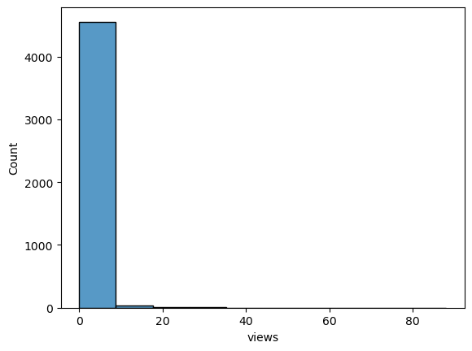

```python
# Visualize views with histogram

sns.histplot(data=data_raw1, x='views', bins=10)
```

This histogram looks highly skewed. It appears that the number of views is predominantly below 10 for the listed hotels.

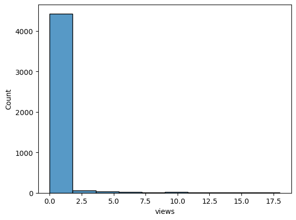

```python
below20views = data_raw1[data_raw1['views'] < 20]

sns.histplot(below20views, x='views', bins=10)
```

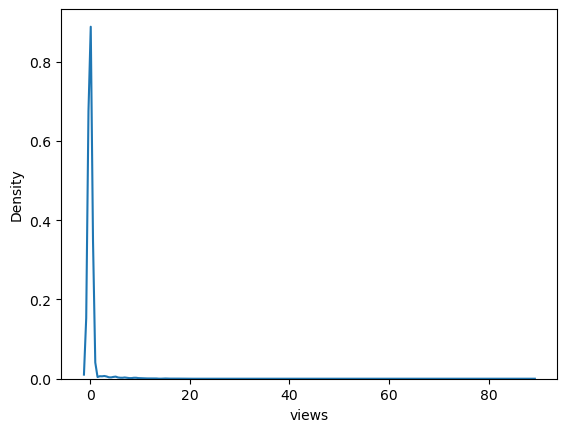

```python
# show skewedness with kdeplot

sns.kdeplot(data=data_raw1, x='views')
```

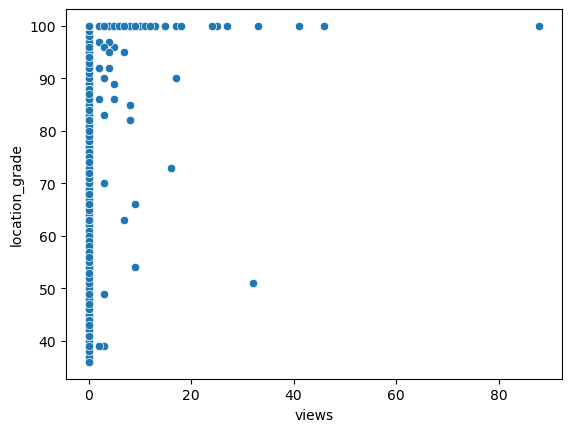

```python
sns.scatterplot(data=data_raw1, x='views', y='location_grade' )
```

This scatterplot depicts that the location_grade, on a scale to 100, has a limited or partially ambiguous relationship to the number of views. It seems, however, that there might be a weak positive link, because majoritely for higher grades, higher amounts of views are visible.

In line with the histograms and kdeplot of the views variable, most observations can be attributed to 0 or close to 0 views.

```python
data_raw1['class'].unique()
```

```
array(['3', '4', '5', '2', '1', 'no stars'], dtype=object)
```

```python
data_raw1['class'].replace({'no stars': 0}, inplace=True)

data_raw1['class'] = data_raw1['class'].astype(int)

data_raw1['class'].unique()
```

```
array([3, 4, 5, 2, 1, 0])
```

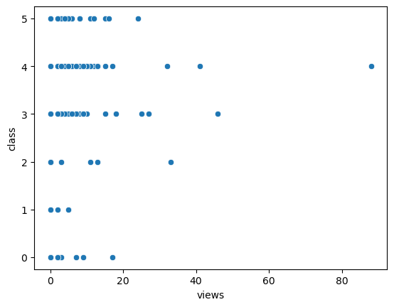

```python
sns.scatterplot(data=data_raw1, x='views', y='class' )
```

### Define and remove outliers in 'views'

```python
# detect outliers in views using the z-score

def calculate_z_score(data):
    mean = np.mean(data)
    std_dev = np.std(data)
    z_scores = (data - mean) / std_dev
    return z_scores

z_scores = calculate_z_score(data_raw1['views'])


z_scores
```

```
0       -0.123092
1       39.320014
2       14.219856
3        7.496599
4       -0.123092
          ...
4594    -0.123092
4595    -0.123092
4596    -0.123092
4597    -0.123092
4598    -0.123092
Name: views, Length: 4599, dtype: float64
```

```python
outliers_indeces = []

mean_views = np.mean(data_raw1['views'])
std_dev_views = np.std(data_raw1['views'])

for idx, z in enumerate(z_scores):
    if z > 3:
        outliers_indeces.append(idx)

len(outliers_indeces)
```

```
64
```

```python
# drop outliers from data_raw1: data_raw2

data_raw1.drop(outliers_indeces, axis=0, inplace=True)

len(data_raw1)
```

```
4535
```

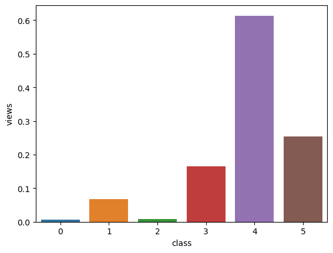

```python
# recreate scatterplot by hotel class to visualize data without outliers

sns.barplot(data=data_raw1, x='class', y='views', errorbar=None)
```

### Remove columns with too little data

```python
# cols with many NA values
n_rows = len(data_raw1)
missing_values_features = []

for c in data_raw1.columns:
    if data_raw1[c].count()/n_rows < 0.75:
        missing_values_features.append(c)

print(missing_values_features)
```

```
['price_curr_min']
```

```python
data_raw1.drop(columns='price_curr_min', inplace=True)
```

```python
data_raw1['views'].value_counts()
```

```
views
0    4427
3      31
2      29
5      25
4      13
6      10
Name: count, dtype: int64
```

Due to the highly imbalanced distribution of the views variable, I have chosen to reintroduce a binary version of the variable to better support analysis.

This binary indicator (viewed), which distinguishes between listings with zero and non-zero views, simplifies the target and addresses the sparsity of meaningful signal in the original count data. By focusing on whether a listing was viewed at all, rather than how many times, the analysis can more effectively identify features associated with visibility while avoiding issues related to class imbalance and low granularity in the original variable.

```python
# use data_raw1 but add the binary variable again

data_raw1['views'] = np.where(data_raw1['views'] > 0, 1, data_raw1['views'])
```

```python
# check the binary distribution in views after transformation

view_counts = data_raw1['views'].value_counts()
view_percs = data_raw1['views'].value_counts(normalize=True)
pd.concat([view_counts,round(view_percs,2)], axis=1, keys=['count', 'percentage'])
```

| views | count | percentage |
| --- | --- | --- |
| 0 | 4427 | 0.98 |
| 1 | 108 | 0.02 |

Due to the still prevailing class imbalance between viewed and not viewed, where only 2% of all hotels have any views, we might have to stratify the dataset to overcome those limitations that can create strong bias when looking at causal relationships and feature importance.

# Machine Learning for Feature Importance

https://www.sciencedirect.com/science/article/pii/S2215016123005241

### Working with an imbalanced dataset: Stratification

Because predictive classification models usually result in poor performance on the minority class, in our case the `viewed` class, which makes up for 2% of the observations, we need to address this issue when applying a Machine Learning model onto this dataset.

```python
# import necessary ML packages

from sklearn.model_selection import  train_test_split
from sklearn.ensemble import RandomForestClassifier
from xgboost import XGBClassifier, plot_importance
from sklearn.impute import KNNImputer
from imblearn.under_sampling import RandomUnderSampler
from imblearn.over_sampling import RandomOverSampler
from sklearn.model_selection import GridSearchCV
from sklearn.metrics import recall_score
```

### Data Preprocessing

```python
data_raw1.columns
```

```
Index(['ID', 'hotel_url', 'name', 'views', 'score_adjusted', 'bubble_rating',
       'category_hotel', 'category_inn', 'category_specialty', 'class',
       ...
       'amenities_Wardrobe / closet', 'amenities_Washing machine',
       'amenities_Water park', 'amenities_Water park offsite',
       'amenities_Waterslide', 'amenities_Waxing services',
       'amenities_Whirlpool bathtub', 'amenities_Wifi',
       'amenities_Wine / champagne', 'amenities_Yoga classes'],
      dtype='object', length=265)
```

Some features seem to be redundant. Therefore, we will exclude redundancy in the following features:

- class_4_5
- class_3_4_5

```python
data_raw1.drop(columns=['class_4_5', 'class_3_4_5'], inplace=True)
```

```python
# nan values

data_raw1.isna().sum().sort_values(ascending=False).head(10)            ## we should exclude price_max and price_min right away due to the low data availability
```

```
price_max                                1127
price_min                                1125
photos                                    577
location_grade                            216
amenities_Patio                             0
amenities_Parking garage                    0
amenities_Parking                           0
amenities_Paid wifi                         0
amenities_Paid public parking on-site       0
amenities_Paid public parking nearby        0
dtype: int64
```

```python
# check for photos for potential imputation

data_raw1['photos'].value_counts().sort_index()                     ## impute 1 instead of NaN, as there are no 0 counts in the data (by ASSUMPTION that every hotel shows at least 1 photo)
```

```
photos
2.0        75
3.0        73
4.0        64
5.0       272
6.0       153
         ...
1372.0      1
1382.0      1
1423.0      1
1520.0      1
1589.0      1
Name: count, Length: 553, dtype: int64
```

```python
# check for location_grade for potential imputation

data_raw1['location_grade'].value_counts().sort_index()         ## impute the location_grade given by the hotel's 'Nearest Neighbor', in a statistical way of speaking
```

```
location_grade
36.0        8
37.0       11
38.0       10
39.0       13
40.0       10
         ...
96.0       38
97.0       53
98.0       48
99.0       78
100.0    2959
Name: count, Length: 65, dtype: int64
```

```python
# drop columns for ML application
data = data_raw1.drop(columns=['ID', 'hotel_url', 'name', 'views', 'price_max', 'price_min'])
```

```python
# photos impute
data['photos'] = data['photos'].fillna(1)
```

```python
# check remaining nan values

data.isna().sum().sort_values(ascending=False).head(3)
```

```
location_grade                           216
score_adjusted                             0
amenities_Paid private parking nearby      0
dtype: int64
```

```python
# KNNImputer to impute location_grade
imputer = KNNImputer(n_neighbors=10, weights='uniform').set_output(transform='pandas')
data = imputer.fit_transform(data)
```

```python
# check remaining nan values

data.isna().sum().sort_values(ascending=False).head(3)
```

```
score_adjusted                   0
amenities_Indoor pool            0
amenities_Outdoor dining area    0
dtype: int64
```

## Data Split for ML model training and testing

```python
# Split df into features and target variable
X = data
y = data_raw1['views']
```

```python
# check for y class distribution
y.value_counts()
```

```
views
0    4427
1     108
Name: count, dtype: int64
```

Now, let's split the data into training and test set

```python
# Split the data into train/test
X_train, X_test, y_train, y_test = train_test_split(
    X, y, test_size=0.2, random_state=100, stratify=y)
```

```python
round(y_train.value_counts(normalize=True),2)
```

```
views
0    0.98
1    0.02
Name: proportion, dtype: float64
```

```python
round(y_test.value_counts(normalize=True),2)
```

```
views
0    0.98
1    0.02
Name: proportion, dtype: float64
```

The overall value distribution in the target variable has been preserved after splitting the data, as the training as well as the test set display 2% positive variables of y.

Now, it is important to create a class balance for the training set that will allow to create a less biased model for a higher generalization and better predictive performance.

For this, the disparity between classes will first be smoothed. Next, we will compare different ML models using Cross Validation to enable a more generalized performance overview, and then pick the best performing model on the test set to retrieve feature importance, since the best performing model is able to capture the complexity and variance in the data the best.

### Random Under Sampler

```python
# Perform under sampling to create balanced dataset
rus = RandomUnderSampler(random_state=100)

X_train_rus, y_train_rus = rus.fit_resample(X_train, y_train)
```

```python
y_train_rus.value_counts()
```

```
views
0    86
1    86
Name: count, dtype: int64
```

### Random Over Sampler

```python
ros = RandomOverSampler(random_state=100)

X_train_ros, y_train_ros = ros.fit_resample(X_train, y_train)
```

```python
y_train_ros.value_counts()
```

```
views
0    3542
1    3542
Name: count, dtype: int64
```

So now, we will work separately with Random Over Sampling as well as Random Under Sampling on the chosen ML models. This will allow us to draw conclusions on which approach was better suited for this data, given that both could have advantages and disadvantages over the other.

## ML with Undersampling and Oversampling

### Choice of Metrics

As for metrics, the metric of choice to choose the best performing ML model will be Recall, also known as the True Positive Rate. The reason for that is that we want to detect as many actual positives, so actually viewed and successful hotels, as possible.

### Applying Random Forest

```python
cv_params = {'max_depth': [3,5,7],
             'min_samples_leaf': [2,3,4],
             'min_samples_split': [2,3,4],
             'max_features': [4,8,12],
             'n_estimators': [50, 75, 100]
             }

# Deine the scoring metrics
scoring = 'recall'

rf_u = GridSearchCV(RandomForestClassifier(),
                           param_grid=cv_params, cv=5, scoring=scoring)
rf_o = GridSearchCV(RandomForestClassifier(),
                           param_grid=cv_params, cv=5, scoring=scoring)
```

```python
# Fit undersampled model
rf_u.fit(X_train_rus, y_train_rus)

# Fit oversampled model
rf_o.fit(X_train_ros, y_train_ros)
```

```
GridSearchCV(cv=5, estimator=RandomForestClassifier(),
             param_grid={'max_depth': [3, 5, 7], 'max_features': [4, 8, 12],
                         'min_samples_leaf': [2, 3, 4],
                         'min_samples_split': [2, 3, 4],
                         'n_estimators': [50, 75, 100]},
             scoring='recall')
```

```python
print('Random Forest Undersampling:', rf_u.best_estimator_, 'score:', rf_u.best_score_)

print('Random Forest Oversampling:', rf_o.best_estimator_, 'score:', rf_o.best_score_)
```

```
Random Forest Undersampling: RandomForestClassifier(max_depth=3, max_features=4, min_samples_leaf=2,
                       min_samples_split=4, n_estimators=50) score: 0.9411764705882353
Random Forest Oversampling: RandomForestClassifier(max_depth=7, max_features=12, min_samples_leaf=3,
                       min_samples_split=4, n_estimators=50) score: 0.982781509725642
```

```python
# undersampling prediction on test set

rf_u_model = rf_u.best_estimator_
rf_u_model.random_state = 99
rf_u_model.fit(X_train_rus, y_train_rus)

rf_u_pred = rf_u_model.predict(X_test)


print('Recall:', recall_score(y_test,
                              rf_u_pred,
                              average="weighted"))
```

```
Recall: 0.8974641675854466
```

```python
# oversampling prediction on test set

rf_o_model = rf_o.best_estimator_
rf_u_model.random_state = 99
rf_o_model.fit(X_train_ros, y_train_ros)

rf_o_pred = rf_o_model.predict(X_test)


print('Recall:', recall_score(y_test,
                              rf_o_pred,
                              average="weighted"))
```

```
Recall: 0.9437706725468578
```

It appears that the oversampling random forest model performs considerably better respective to the recall score, compared to the undersampling model. Therefore, we choose the oversampling random forest, which shows a recall score of 94.4%, to later compare with the alternative ML model

### Applying XGBoost

```python
cv_params_xgb = {
        'subsample': [0.3, 0.5, 0.7],
        'colsample_bytree': [0.6, 0.8, 1.0],
        'max_depth': [3, 5, 7],
        'learning_rate': [0.1, 0.05, 0.01,],
        'alpha': [0.25, 0.5, 0.75]
        }
```

```python
# Deine the scoring metrics
scoring = 'recall'

xgb_u = GridSearchCV(XGBClassifier(),
                           param_grid=cv_params_xgb, cv=5, scoring=scoring)
xgb_o = GridSearchCV(XGBClassifier(),
                           param_grid=cv_params_xgb, cv=5, scoring=scoring)
```

```python
# Fit undersampled model
xgb_u.fit(X_train_rus, y_train_rus)

# Fit oversampled model
xgb_o.fit(X_train_ros, y_train_ros)
```

```
GridSearchCV(cv=5,
             estimator=XGBClassifier(base_score=None, booster=None,
                                     callbacks=None, colsample_bylevel=None,
                                     colsample_bynode=None,
                                     colsample_bytree=None, device=None,
                                     early_stopping_rounds=None,
                                     enable_categorical=False, eval_metric=None,
                                     feature_types=None, feature_weights=None,
                                     gamma=None, grow_policy=None,
                                     importance_type=None,
                                     interaction_constraints=Non...
                                     max_delta_step=None, max_depth=None,
                                     max_leaves=None, min_child_weight=None,
                                     missing=nan, monotone_constraints=None,
                                     multi_strategy=None, n_estimators=None,
                                     n_jobs=None, num_parallel_tree=None, ...),
             param_grid={'alpha': [0.25, 0.5, 0.75],
                         'colsample_bytree': [0.6, 0.8, 1.0],
                         'learning_rate': [0.1, 0.05, 0.01],
                         'max_depth': [3, 5, 7], 'subsample': [0.3, 0.5, 0.7]},
             scoring='recall')
```

```python
print('XGB Undersampling:', xgb_u.best_params_, 'score:', xgb_u.best_score_)

print('XGB Oversampling:', xgb_o.best_params_, 'score:', xgb_o.best_score_)
```

```
XGB Undersampling: {'alpha': 0.5, 'colsample_bytree': 1.0, 'learning_rate': 0.1, 'max_depth': 3, 'subsample': 0.7} score: 0.9411764705882353
XGB Oversampling: {'alpha': 0.25, 'colsample_bytree': 0.6, 'learning_rate': 0.1, 'max_depth': 3, 'subsample': 0.3} score: 1.0
```

```python
# undersampling prediction on test set

xgb_u_model = XGBClassifier(**xgb_u.best_params_)

xgb_u_model.fit(X_train_rus, y_train_rus)

xgb_u_pred = xgb_u_model.predict(X_test)

print('Recall:', recall_score(y_test,
                              xgb_u_pred,
                              average="weighted"))
```

```
Recall: 0.9206174200661521
```

```python
# oversampling prediction on test set

xgb_o_model = XGBClassifier(**xgb_o.best_params_)

xgb_o_model.fit(X_train_ros, y_train_ros)

xgb_o_pred = xgb_o_model.predict(X_test)

print('Recall:', recall_score(y_test,
                              xgb_o_pred,
                              average="weighted"))
```

```
Recall: 0.9614112458654906
```

### Ultimate Comparison: Over- vs. Undersampling & Random Forest vs. Extreme Gradient Boosting

```python
# combine the metrics into one table/overview

metrics = pd.DataFrame({
    'Model': ['Random Forest (Undersampling)', 'Random Forest (Oversampling)',
              'XGBoost (Undersampling)', 'XGBoost (Oversampling)'],
    'Recall': [recall_score(y_test, rf_u_pred, average="weighted"),
               recall_score(y_test, rf_o_pred, average="weighted"),
               recall_score(y_test, xgb_u_pred, average="weighted"),
               recall_score(y_test, xgb_o_pred, average="weighted")],

})

metrics
```

|  | Model | Recall |
| --- | --- | --- |
| 0 | Random Forest (Undersampling) | 0.897464 |
| 1 | Random Forest (Oversampling) | 0.943771 |
| 2 | XGBoost (Undersampling) | 0.920617 |
| 3 | XGBoost (Oversampling) | 0.961411 |

As becomes visible in the summary above, the best performing model on the test set was XGBoost, using the approach of oversampling (which we used to balance out our data for better results on the test set). Hence, the XGBoost model with oversampling achieved the best recall, achieving a score of 96.14% on the test set!

Now, after having found the best model, we can proceed to find the most important features that led the model to such high model performance. Remember that the overall objective of this is to leverage ML as a tool for feature selection and to get an idea of which features are most important to predict the class of views on a TripAdvisor Hotel listing. On these most important features, we will then perform Causal Inference / Discovery, in order to measure causal relationships between features/hotel characteristics and the target variable of views.

```python
best_model = xgb_o_model
```

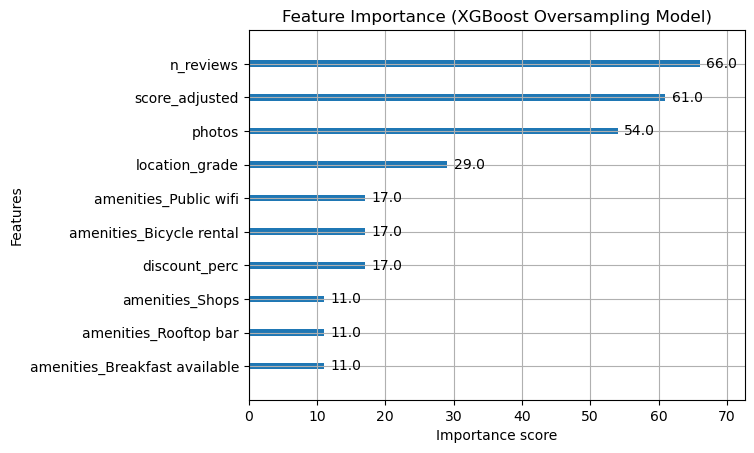

```python
# Visualize the feature importance of the XGBoost oversampling model

plot_importance(best_model, importance_type='weight', max_num_features=10)
plt.title("Feature Importance (XGBoost Oversampling Model)")
plt.show()
```

We will now choose a reasonable cut-off point that allows some sort of comparability between the feature importances. In other words, we can see a clear distinction in the importance and contribution of the first three features, being `score_adjusted`, `n_reviews`, and `photos`. These three features seem to be most promissing in find any causal impact to the outcome of our target variable. I propose to also include the `location_grade`, because it might be relevant as well and still showcases a certain significance on the feature importance scale.

Let's now begin our Causal Discovery!

# Causal Discovery

```python
data.columns
```

```
Index(['score_adjusted', 'bubble_rating', 'category_hotel', 'category_inn',
       'category_specialty', 'class', 'n_reviews', 'location_grade',
       'discount', 'discount_perc',
       ...
       'amenities_Wardrobe / closet', 'amenities_Washing machine',
       'amenities_Water park', 'amenities_Water park offsite',
       'amenities_Waterslide', 'amenities_Waxing services',
       'amenities_Whirlpool bathtub', 'amenities_Wifi',
       'amenities_Wine / champagne', 'amenities_Yoga classes'],
      dtype='object', length=257)
```

```python
# First create a new dataset with only the target variable as well as the 6 selected features

cd_data = pd.concat([data[['n_reviews', 'score_adjusted', 'photos', 'location_grade']], y], axis=1)
```

```python
cd_data
```

|  | n_reviews | score_adjusted | photos | location_grade | views |
| --- | --- | --- | --- | --- | --- |
| 0 | 154.0 | 4.409091 | 135.0 | 100.0 | 0 |
| 4 | 1068.0 | 4.624299 | 784.0 | 100.0 | 0 |
| 6 | 3457.0 | 4.744650 | 1382.0 | 100.0 | 0 |
| 12 | 2905.0 | 4.507221 | 1148.0 | 100.0 | 1 |
| 14 | 2033.0 | 4.046706 | 669.0 | 100.0 | 1 |
| ... | ... | ... | ... | ... | ... |
| 4594 | 15.0 | 1.733333 | 3.0 | 96.0 | 0 |
| 4595 | 9.0 | 1.888889 | 2.0 | 100.0 | 0 |
| 4596 | 11.0 | 2.090909 | 9.0 | 100.0 | 0 |
| 4597 | 98.0 | 2.000000 | 54.0 | 100.0 | 0 |
| 4598 | 376.0 | 1.686170 | 268.0 | 100.0 | 0 |

4535 rows × 5 columns

```python
cd_data.info()
```

```
<class 'pandas.core.frame.DataFrame'>
Index: 4535 entries, 0 to 4598
Data columns (total 5 columns):
 #   Column          Non-Null Count  Dtype
---  ------          --------------  -----
 0   n_reviews       4535 non-null   float64
 1   score_adjusted  4535 non-null   float64
 2   photos          4535 non-null   float64
 3   location_grade  4535 non-null   float64
 4   views           4535 non-null   int64
dtypes: float64(4), int64(1)
memory usage: 212.6 KB
```

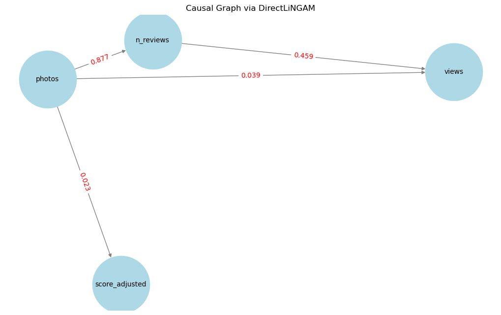

```python
# import library for causal discovery and inference
from lingam import DirectLiNGAM
import networkx as nx
from sklearn.preprocessing import StandardScaler

scaler = StandardScaler()
cd_data_scaled = pd.DataFrame(
    scaler.fit_transform(cd_data),
    columns=cd_data.columns)

# Fit DirectLiNGAM on scaled data
model = DirectLiNGAM()
model.fit(cd_data_scaled)

# Extract adjacency matrix
adj_matrix = model.adjacency_matrix_
causal_df = pd.DataFrame(adj_matrix, index=cd_data.columns, columns=cd_data.columns)

# Create a causal graph
DAG = nx.DiGraph()

for i, source in enumerate(cd_data.columns):
    for j, target in enumerate(cd_data.columns):
        weight = adj_matrix[i, j]
        if abs(weight) > 0.0:
            DAG.add_edge(source, target, weight=round(weight, 3))

# Draw graph
pos = nx.spring_layout(DAG)
edge_labels = nx.get_edge_attributes(DAG, 'weight')

plt.figure(figsize=(10, 6))
nx.draw(DAG, pos, with_labels=True, node_color='lightblue', edge_color='gray', node_size=7000, font_size=10)
nx.draw_networkx_edge_labels(DAG, pos, edge_labels=edge_labels, font_color='red')
plt.title("Causal Graph via DirectLiNGAM")
plt.show()
```

```python
causal_df = pd.DataFrame(
    adj_matrix,
    index=cd_data.columns,
    columns=cd_data.columns
)

effects_df = causal_df[(causal_df != 0)].stack().reset_index()
effects_df.columns = ['Cause', 'Effect', 'Strength']

print(effects_df.sort_values(by='Strength', ascending=False))
```

```
       Cause          Effect  Strength
1     photos       n_reviews  0.876846
0  n_reviews           views  0.459328
3     photos           views  0.038678
2     photos  score_adjusted  0.022530
```

Here with have now created our first Causal Graph using DirectLiNGAM method.

We can try to make sense out of this DAG and make some assumptions to create a more realistic view on causal relationships towards the target variable `views`.

From the relationships and their strengths, the following are worth noting:

- Photos strongly impact the number of reviews, with an effect of 0.877.
- The number of reviews has a moderate, direct effect onto the binary target variable `views`, with a causal effect of 0.459.
- Photos have a very weak effect on views and on the adjusted score given.